# R markdown group 1

Silje Johansen // Fabian Gärtner // Anna Kleppe Moe

2024-09-19

## Data

Our original dataset consisted of 1162 observations of 20 variables. These were data on 581 patients, with main variable being abm, (presence of acute bacterial meningitis). There were variables on different proteins and cells in blood samples and cerebrospinal fluid samples obtained from the patients, as well as basic demographics such as sex, age, race, date of sampling…

## Tidy and wrangling data

To tidy our data we…

- explored using different functions such as head, tail, summary, glimpse, skimr::skim, naniar::gg_miss_var
- changed feature type and feature_value by “pivot wider” function to new “sex” and “race” variables. This helped us to reduce the observations to 581 (one per id instead of two).
- changed the date variable to a format easier to understand
- added a new age2 variable easier to understand as character in years and months
- added new variable demonstrating `blood_neut_pct` as high/low (>35)
- added new variable with blood_cult as percentage (blood_cult / highest blood cult)
- added new variable with sex as a numeric variable, sex_as_factor
- reduced number of decimals in some variables
- renamed variables to be more intuitive, especially main outcome variable abm to “acute_bacterial_meningitis”
- ordered the columns specifically, and arranged id column increasingly

## Additional data set

The additional dataset only contained id variable and csf_gluc variable, which we already had in our first dataset. Still, we fully joined these two dataset, successfully. We did several assignments stratifying (group_by) by sex, filtering for different things (blood_cult=0, race), and reported minimum, maximum, mean and sd values using “summarise”.

## Plots

#### 1. To analyze if the glucose level in blood depends on sex, we did boxplot, t-test and mann u whitney test.

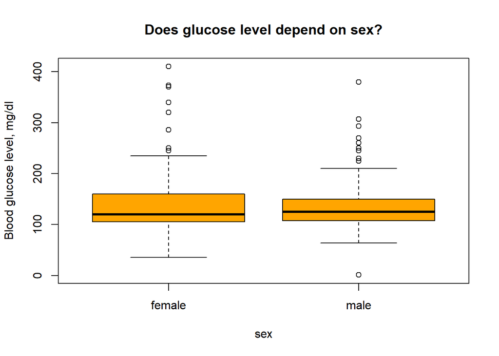

```
##
##  Welch Two Sample t-test
##
## data:  blood_gluc by sex
## t = 1.4351, df = 258.53, p-value = 0.1525
## alternative hypothesis: true difference in means between group female and group male is not equal to 0
## 95 percent confidence interval:
##  -3.349256 21.348945
## sample estimates:
## mean in group female   mean in group male
##             143.0278             134.0279
```

```
##
##  Wilcoxon rank sum test with continuity correction
##
## data:  blood_gluc by sex
## W = 13258, p-value = 0.6577
## alternative hypothesis: true location shift is not equal to 0
```

#### 2. To analyze if the glucose level in blood depends on race, we did boxplot and kruskal-wallis test.

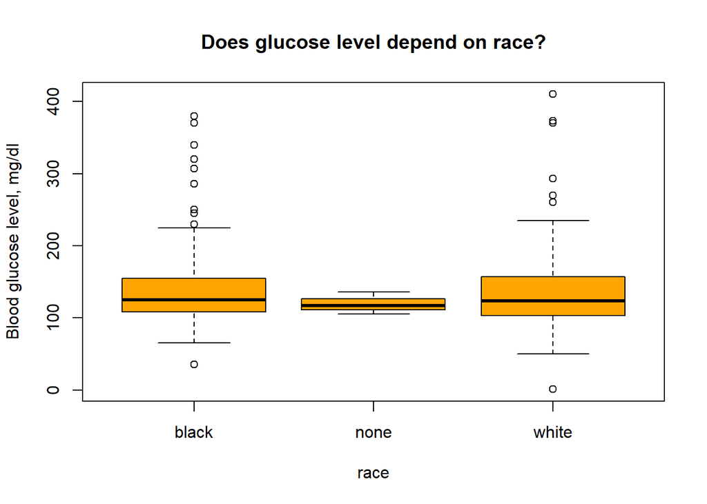

```
##
##  Kruskal-Wallis rank sum test
##
## data:  blood_gluc by race
## Kruskal-Wallis chi-squared = 0.47336, df = 2, p-value = 0.7892
```

#### 3. To analyze if the glucose level in CSF (cerebrospinal fluid) depends on race, we did boxplot and kruskal-wallis test.

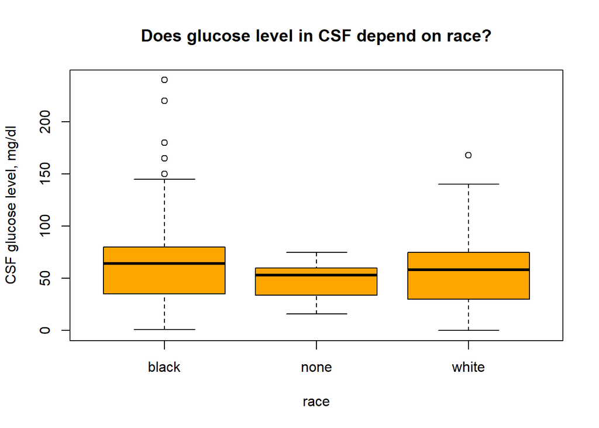

```
##
##  Kruskal-Wallis rank sum test
##
## data:  csf_gluc.x by race
## Kruskal-Wallis chi-squared = 4.2652, df = 2, p-value = 0.1185
```

#### 4. To analyze if the glucose level in CSF (cerebrospinal fluid) depends on sex, we did boxplot and kruskal-wallis test.

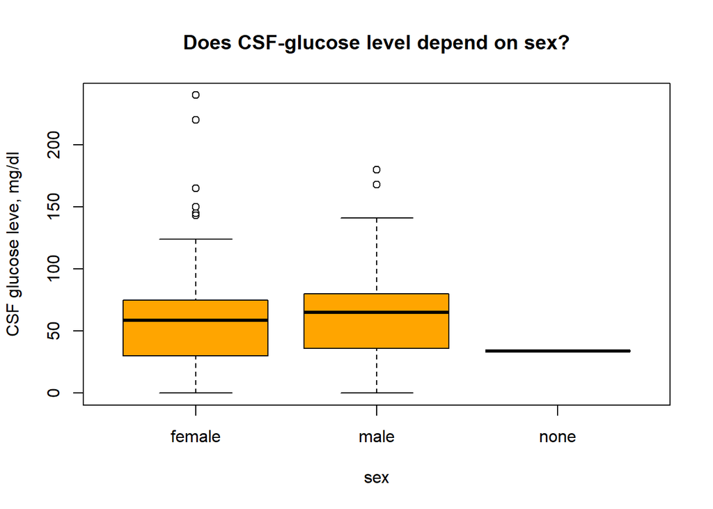

```
##
##  Kruskal-Wallis rank sum test
##
## data:  csf_gluc.x by sex
## Kruskal-Wallis chi-squared = 3.6089, df = 2, p-value = 0.1646
```

## Statistical analyses

#### 1. We analyzed if there is a difference in the occurrence of the disease (acute baterial meningitis) by sex, by making a cross-table and chi-square test.

```
##
##          non-bacterial meningitis bacterial meningitis
##   male                        118                  113
##   female                       85                  104
```

```
##
##  Pearson's Chi-squared test with Yates' continuity correction
##
## data:  table_data
## X-squared = 1.3183, df = 1, p-value = 0.2509
```

#### 2. We analyzed if the occurance of ABM depends on age, by doing a t-test.

```
##
##  Welch Two Sample t-test
##
## data:  age by acute_bacterial_meningitis
## t = 0.97651, df = 375.55, p-value = 0.3294
## alternative hypothesis: true difference in means between group 0 and group 1 is not equal to 0
## 95 percent confidence interval:
##  -1.872463  5.567171
## sample estimates:
## mean in group 0 mean in group 1
##        14.51970        12.67235
```

#### 3. We analyzed if there is a difference in occurance of ABM by race, by making a table and doing a chi-square test.

```
##
##         non-bacterial meningitis bacterial meningitis
##   black                      119                  125
##   none                        83                    1
##   white                       82                   91
```

```
##
##  Pearson's Chi-squared test
##
## data:  table_data2
## X-squared = 73.009, df = 2, p-value < 2.2e-16
```